# Case Study: Bike-Share

```r
trips_data_casual_weekend <- NROW(filter(trips_data_clean, member_casual == "casual" & (day_of_week == "Saturday" | day_of_week == "Sunday")))
print(paste("Total casual rides taken on weekend:", trips_data_casual_weekend))
```

```
[1] "Total casual rides taken on weekend: 554639"
```

```r
# Calculate the total rides on weekdays vs weekend taken by members
trips_data_member_weekday <- NROW(filter(trips_data_clean, member_casual == "member" & !(day_of_week == "Saturday" | day_of_week == "Sunday")))
print(paste("Total rides taken by members on weekday:", trips_data_member_weekday))
```

```
[1] "Total rides taken by members on weekday: 1546470"
```

```r
trips_data_member_weekend <- NROW(filter(trips_data_clean, member_casual == "member" & (day_of_week == "Saturday" | day_of_week == "Sunday")))
print(paste("Total rides taken by members on weekend:", trips_data_member_weekend))
```

```
[1] "Total rides taken by members on weekend: 564633"
```

```r
#Percentage of casual riders on weekdays vs weekend
labs <- c("% of casual riders on Weekday", "% of casual riders on Weekend")
slices_casual_week <- c(trips_data_casual_weekday, trips_data_casual_weekend)
piepercent <- round(100 * slices_casual_week / sum(slices_casual_week), 1)
lbls <- paste(labs, piepercent)
lbls_casual_week <- paste(lbls, "%", sep="")
lbls_casual_week
```

```
[1] "% of casual riders on Weekday 58%" "% of casual riders on Weekend 42%"
```

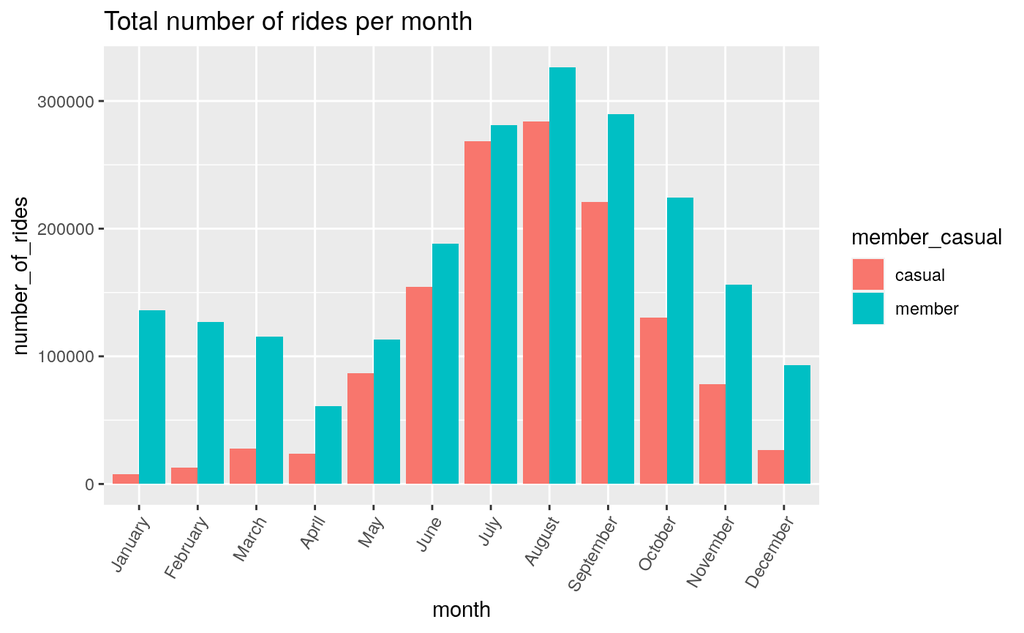

```r
# Calculate total number of rides per month grouped by rider type
trips_data_clean %>%
  group_by(member_casual, month) %>%
  summarise(number_of_rides = n(), average_duration = mean(ride_length)) %>%
  arrange(member_casual, month) %>%
  ggplot(aes(x = month, y = number_of_rides, fill = member_casual)) +
  geom_col(position = "dodge") +
  labs(title="Total number of rides per month") +
  scale_y_continuous(labels = function(x) format(x, scientific = FALSE))+
  theme(axis.text.x = element_text(angle = 60, hjust = 1))
```

The graph shows that the months of July, August and September is when there is the highest demand for bikes during the year among both members and casual riders.

```r
#Average number of trips by customer type and month
trips_data_clean %>%
  group_by(member_casual, month) %>%
  summarise(number_of_rides = n(),`average_ride_mins` = mean(ride_length)) %>%
  arrange(member_casual,month) %>% print(n=30)
```

| member_casual | month | number_of_rides | average_ride_mins |
| --- | --- | --- | --- |
| casual | January | 7785 | 161.64948 |
| casual | February | 12860 | 127.63018 |
| casual | March | 27625 | 63.12423 |
| casual | April | 23592 | 73.18281 |
| casual | May | 86780 | 51.25527 |
| casual | June | 154393 | 51.71925 |
| casual | July | 268444 | 59.99875 |
| casual | August | 283868 | 45.37898 |
| casual | September | 220711 | 38.94099 |
| casual | October | 130567 | 31.60257 |

[output cut: 14 more lines]

```r
# n=30, because by default the tibble was only showing 10 rows
```

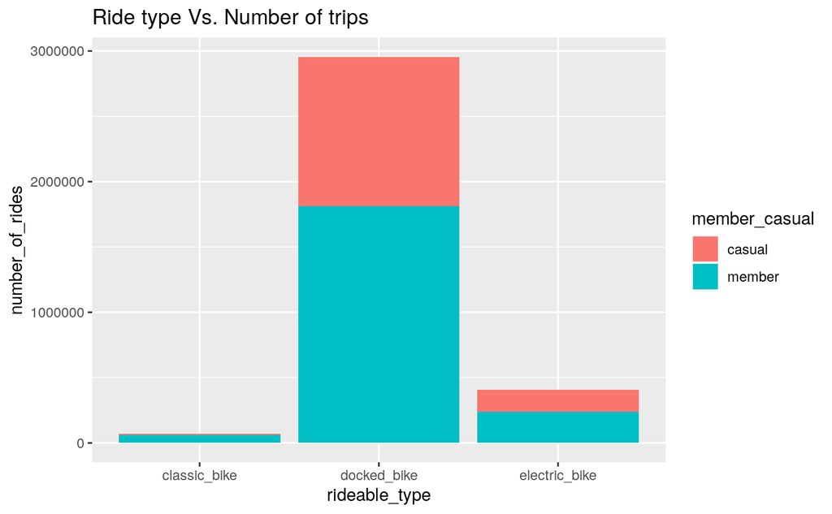

```r
# ride type vs members or casual riders
trips_data_clean %>%
  group_by(rideable_type,member_casual) %>%
  summarise(number_of_rides = n()) %>%
  ggplot(aes(x= rideable_type, y=number_of_rides, fill= member_casual))+
  geom_bar(stat='identity') +
  scale_y_continuous(labels = function(x) format(x, scientific = FALSE)) +
  labs(title ="Ride type Vs. Number of trips")
```

- Classic bikes are mainly used by members.
- Docked bikes has the highest demand by both members and casual riders.
- Electric bikes also see a higher demand by members than casual riders.

```r
#Calculate the total casual rides by month - July to September vs rest of the year
total_rides_casual_jul_sept <- NROW(filter(trips_data_clean, member_casual == "casual" & (month == "July" | month == "August" | month == "September")))
print(paste("Total rides taken by casual riders from July to September:", total_rides_casual_jul_sept))
```

```
[1] "Total rides taken by casual riders from July to September: 773023"
```

```r
total_rides_casual_oct_jun <- NROW(filter(trips_data_clean, member_casual == "casual" & !(month == "July" | month == "August" | month == "September")))
print(paste("Total rides taken by casual riders for rest of the year:", total_rides_casual_oct_jun))
```

```
[1] "Total rides taken by casual riders for rest of the year: 548494"
```

```r
#Percentage of casual riders by month - July to September vs rest of the year
labs <- c("% of casual riders from July To September", "% of casual riders for rest of the year")
slices_casual_month <- c(total_rides_casual_jul_sept, total_rides_casual_oct_jun)
piepercent <- round(100 * slices_casual_month / sum(slices_casual_month), 1)
lbls <- paste(labs, piepercent)
lbls_casual_month <- paste(lbls, "%", sep="")
lbls_casual_month
```

```
[1] "% of casual riders from July To September 58.5%" "% of casual riders for rest of the year 41.5%"
```

```r
#Calculate the total member rides by month - July to September compared to rest of the year
total_rides_member_jul_sept <- NROW(filter(trips_data_clean, member_casual == "member" & (month == "July" | month == "August" | month == "September")))
print(paste("Total rides taken by members from July to September:", total_rides_member_jul_sept))
```

```
[1] "Total rides taken by members from July to September: 897179"
```

```r
total_rides_member_oct_jun <- NROW(filter(trips_data_clean, member_casual == "member" & !(month == "July" | month == "August" | month == "September")))
print(paste("Total rides taken by members for rest of the year:", total_rides_member_oct_jun))
```

```
[1] "Total rides taken by members for rest of the year: 1213924"
```

```r
#Percentage of member rides by month - July to September compared to rest of the year
labs <- c("% of member rides from July To September", "% of member rides for rest of the year")
slices_member_month <- c(total_rides_member_jul_sept, total_rides_member_oct_jun)
piepercent <- round(100 * slices_member_month / sum(slices_member_month), 1)
lbls <- paste(labs, piepercent)
lbls_member_month <- paste(lbls, "%", sep="")
lbls_member_month
```

```
[1] "% of member rides from July To September 42.5%" "% of member rides for rest of the year 57.5%"
```

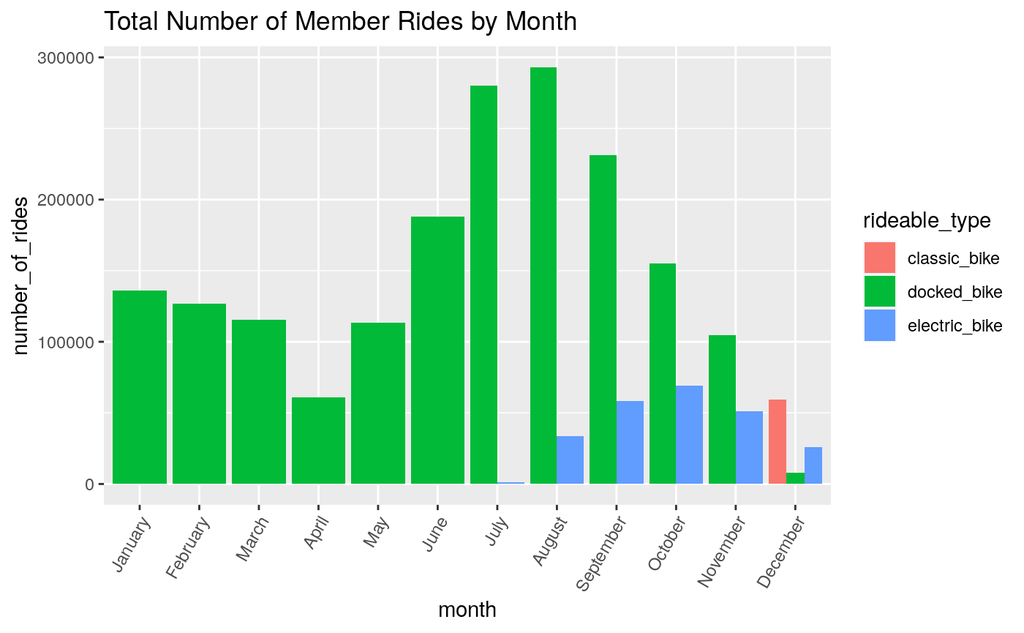

```r
# Create a new data frame for members
trips_member <-  filter(trips_data_clean, member_casual == "member")

#Calculate total number of member rides grouped by month
trips_member %>%
  group_by(rideable_type, month) %>%
  summarise(number_of_rides = n(), average_ride_mins = mean(ride_length)) %>%
  arrange(rideable_type, month) %>%
  ggplot(aes(x = month, y = number_of_rides, fill = rideable_type)) +
  geom_col(position = "dodge") +
  labs(title="Total Number of Member Rides by Month") +
  scale_y_continuous(labels = function(x) format(x, scientific = FALSE))+
  theme(axis.text.x = element_text(angle = 60, hjust = 1))
```

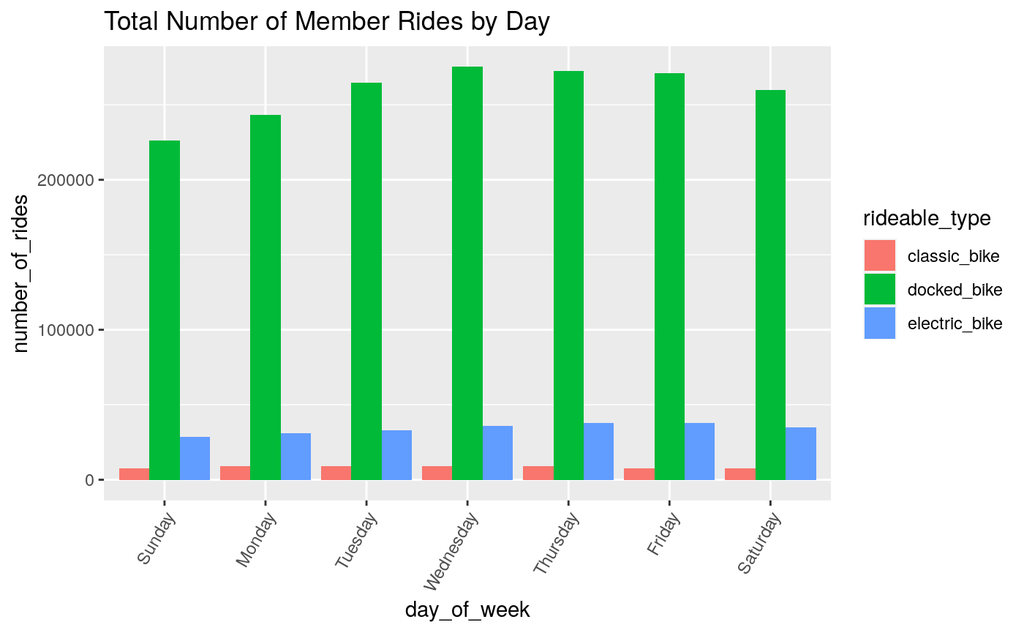

```r
# Calculate total number of member rides grouped by day
trips_member %>%
  group_by(rideable_type, day_of_week) %>%
  summarise(number_of_rides = n(), average_ride_mins = mean(ride_length)) %>%
  arrange(rideable_type, day_of_week)%>%
  ggplot(aes(x = day_of_week, y = number_of_rides, fill = rideable_type)) +
  geom_col(position = "dodge") +
  labs(title="Total Number of Member Rides by Day") +
  scale_y_continuous(labels = function(x) format(x, scientific = FALSE))+
  theme(axis.text.x = element_text(angle = 60, hjust = 1))
```

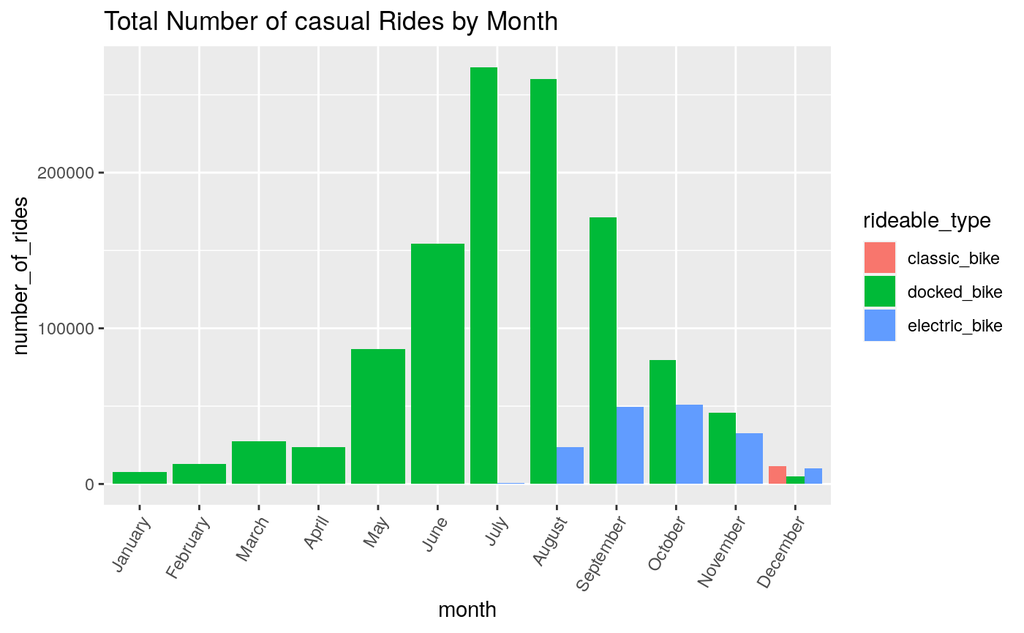

```r
#Create a new data frame for casual riders
trips_casual <-  filter(trips_data_clean, member_casual == "casual")

#Calculate total number of casual rides grouped by month
trips_casual %>%
  group_by(rideable_type, month) %>%
  summarise(number_of_rides = n(), average_ride_mins = mean(ride_length)) %>%
  arrange(rideable_type, month) %>%
  ggplot(aes(x = month, y = number_of_rides, fill = rideable_type)) +
  geom_col(position = "dodge") +
  labs(title="Total Number of casual Rides by Month") +
  scale_y_continuous(labels = function(x) format(x, scientific = FALSE))+
  theme(axis.text.x = element_text(angle = 60, hjust = 1))
```

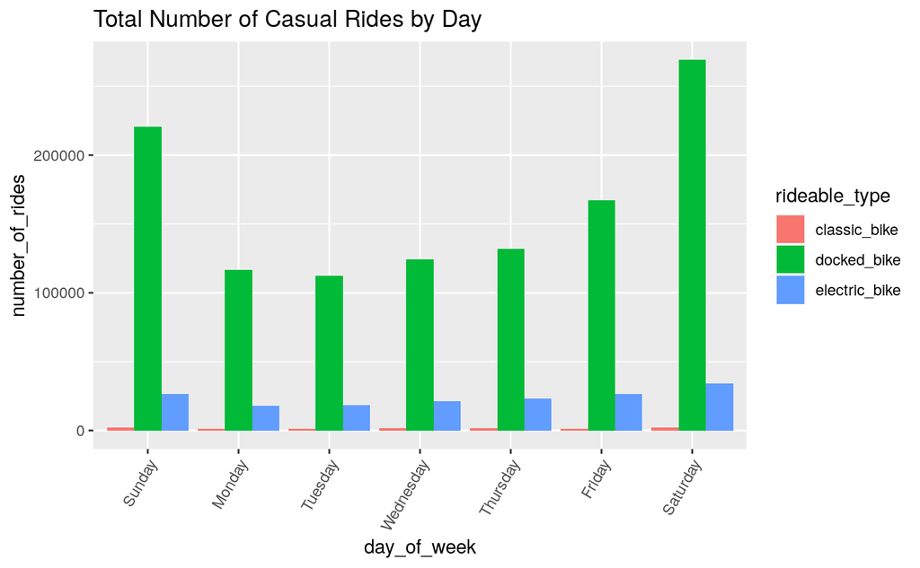

```r
# Calculate total number of casual rides grouped by day
trips_casual %>%
  group_by(rideable_type, day_of_week) %>%
  summarise(number_of_rides = n(), average_ride_mins = mean(ride_length)) %>%
  arrange(rideable_type, day_of_week)%>%
  ggplot(aes(x = day_of_week, y = number_of_rides, fill = rideable_type)) +
  geom_col(position = "dodge") +
  labs(title="Total Number of Casual Rides by Day") +
  scale_y_continuous(labels = function(x) format(x, scientific = FALSE))+
  theme(axis.text.x = element_text(angle = 60, hjust = 1))
```

```r
#In the casual riders data frame, created a new column for route
trips_casual <- trips_casual %>%
  mutate(route = paste(start_station_name, "To", sep=" "))

trips_casual <- trips_casual %>%
  mutate(route = paste(route, end_station_name, sep =" "))

#The most popular route taken by casual riders
popular_route <- trips_casual %>%
  group_by(route) %>%
  summarise(number_of_rides  = n(), average_ride_mins = mean(ride_length)) %>%
  arrange(route, number_of_rides, average_ride_mins)

#Filter the data frame to show just the top 10 routes
popular_route10 <- head(arrange(popular_route, desc(number_of_rides)),10)
head(popular_route10, 10)
```

| route | number_of_rides | average_ride_mins |
| --- | --- | --- |
| Streeter Dr & Grand Ave To Streeter Dr & Grand Ave | 5801 | 59.51055508 |
| Lake Shore Dr & Monroe St To Lake Shore Dr & Monroe St | 5667 | 55.15553379 |
| Buckingham Fountain To Buckingham Fountain | 4669 | 79.36919469 |
| Millennium Park To Millennium Park | 4652 | 58.03925408 |
| Indiana Ave & Roosevelt Rd To Indiana Ave & Roosevelt Rd | 3720 | 63.99720968 |
| HQ QR To HQ QR | 3555 | 0.05398594 |
| Michigan Ave & Oak St To Michigan Ave & Oak St | 3463 | 57.13398498 |
| Fort Dearborn Dr & 31st St To Fort Dearborn Dr & 31st St | 3067 | 72.12415064 |
| Michigan Ave & 8th St To Michigan Ave & 8th St | 3021 | 64.38626283 |
| Shore Dr & 55th St To Shore Dr & 55th St | 2884 | 70.46881415 |

```r
#Create new data frame for members
trips_member <- filter(trips_data_clean, member_casual == "member")

#In the member riders data frame, created a new column for route
trips_member <- trips_member %>%
  mutate(route = paste(start_station_name, "To", sep=" "))

trips_member <- trips_member %>%
  mutate(route = paste(route, end_station_name, sep =" "))

#The most popular route taken by members
popular_route_member <- trips_member %>%
  group_by(route) %>%
  summarise(number_of_rides  = n(), average_ride_mins = mean(ride_length)) %>%
  arrange(route, number_of_rides, average_ride_mins)

#Filter the data frame to show just the top 10 routes
popular_route10_member <- head(arrange(popular_route_member, desc(number_of_rides)),10)
head(popular_route10_member, 10)
```

| route | number_of_rides | average_ride_mins |
| --- | --- | --- |
| MLK Jr Dr & 29th St To State St & 33rd St | 1188 | 7.606145 |
| Lake Shore Dr & Wellington Ave To Lake Shore Dr & Wellington Ave | 1084 | 23.257232 |
| Clark St & Elm St To Clark St & Elm St | 1068 | 17.195234 |
| State St & 33rd St To MLK Jr Dr & 29th St | 1027 | 9.761762 |
| Burnham Harbor To Burnham Harbor | 1007 | 25.961142 |
| Lake Shore Dr & Belmont Ave To Lake Shore Dr & Belmont Ave | 997 | 26.714283 |
| Montrose Harbor To Montrose Harbor | 976 | 22.033914 |
| Theater on the Lake To Theater on the Lake | 974 | 21.372259 |
| Lakefront Trail & Bryn Mawr Ave To Lakefront Trail & Bryn Mawr Ave | 952 | 27.678141 |
| Indiana Ave & Roosevelt Rd To Indiana Ave & Roosevelt Rd | 945 | 23.216519 |

### Share:

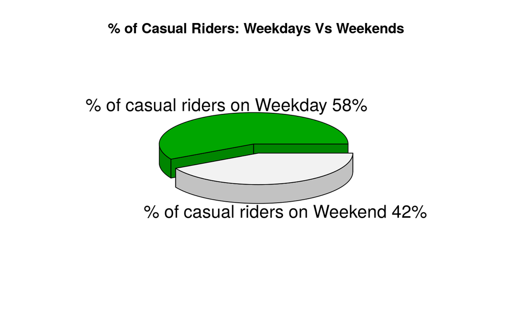

```r
install.packages("plotrix")
library(plotrix)

# casual rides by days
pie3D(slices_casual_week, labels = lbls_casual_week, explode = 0.1, col= terrain.colors(2), main = "% of Casual Riders: Weekdays Vs Weekends")
```

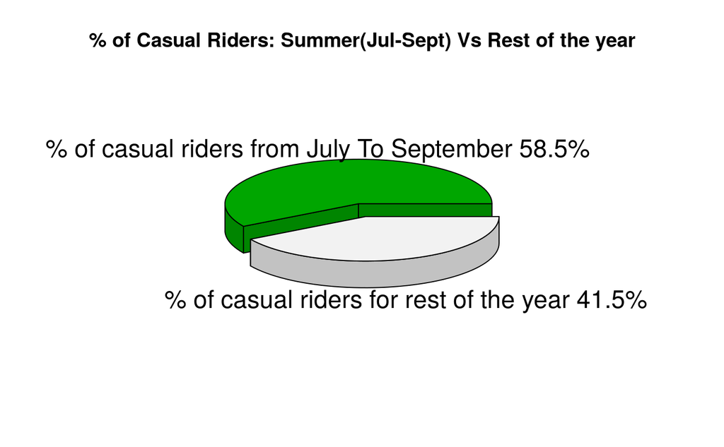

```r
# casual rides by month
pie3D(slices_casual_month, labels = lbls_casual_month, explode = 0.1, col= terrain.colors(2), main = "% of Casual Riders: Summer(Jul-Sept) Vs Rest of the year")
```

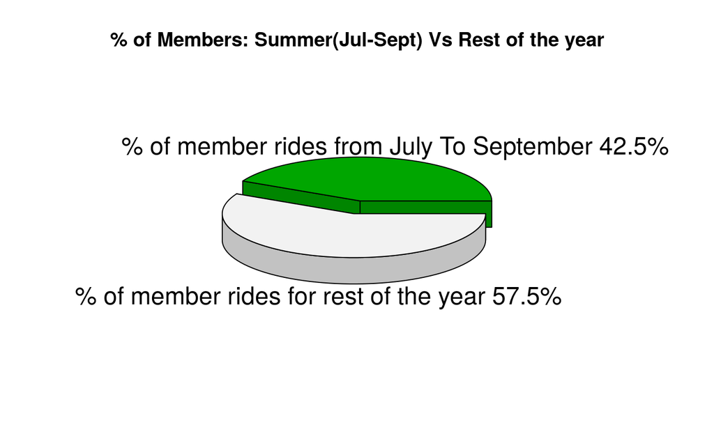

```r
# member rides by month
pie3D(slices_member_month, labels = lbls_member_month, explode = 0.1, col= terrain.colors(2), main = "% of Members: Summer(Jul-Sept) Vs Rest of the year")
```

## Act:

Recommendations for increasing the number of rider membership are:

The highest demands for bikes is seen in the summer months from July to September for both casual riders and members. Almost 60% of the casual rides are during this time, which could be due to tourists and other events.

During these months we could:

- Increase the availability of bikes.
- Weekly, monthly subscription offers.

### Resources

- [CRAN](https://cran.r-project.org)
- [Docker Docs](https://docs.docker.com/engine/reference/commandline/run/)
- [The Rocker Project](https://rocker-project.org)
- [Stack Overflow](https://stackoverflow.com)
- [ggplot2](https://ggplot2.tidyverse.org/reference/scale_continuous.html)